# FinalProject

Koganti, Venkata Rama Sri Harsha

4/5/2022

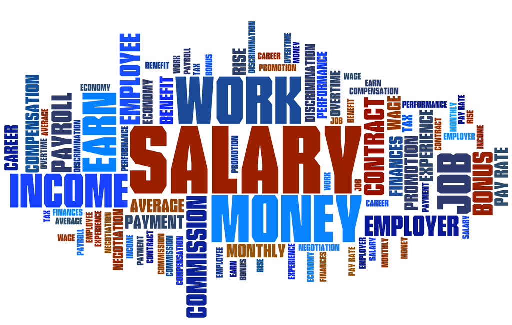

# Abstract

# Introduction

This data was collected in 2008-2009 academic year. This data includes salaries of Assistant Professors, Associate Professors and Professors in a college in the U.S.

**Questions Of Interest**:

- Are there any gender inequality present while considering the salary as the criteria?
- Are the educational systems giving more priority to Applied departments than than the theoretical one?
- Can we determine the salary of a faculty by constructing a multi linear regression equation?
- Are all of the variables necessary to construct the linear regression equation for salaries?
- are there any confounding variables, which the data frame does not have, that can be required to determine the salaries of the faculty using linear regression in a more meaningful way?

**Methods to Answer the questions of interest**:

- Doing **paired t_test** to find weather there is difference in salaries when it comes to categorical variable, like, sex, discipline.
- By using **lm** function I will find the multiple linear regression equation
- By using **BestFit** I will find the best model for which **Adjusted_R^2** will be the highest.
- I will do the analysis on Linear regression equation based on the **Adjusted_R^2**. This will allow me to thing about confounding factors, that might have a significant effect in calculating **salary** using linear regression equation, if they were also collected along with the collected variables.

**Details about the dataframe**

This data frame consists of 397 observations of the following six variables:

**Rank** : a factor with levels AssocProf AsstProf Prof

**discipline** : a factor with levels A (“theoretical” departments) or B (“applied” departments).

**yrs_since_phd** : years since PhD.

**yrs_service** : years of service.

**sex** : a factor with levels Female Male

**salary** : nine-month salary, in dollars.

# Required Packages

- **ggpubr** to draw ggqqplots through which we can find the normality of sample data set
- **tidyverse** For data wrangling, piping, datavisulization.
- **rstatix** Pipe Friendliy R-Functions for statistical analyses.
- **gridExtra** For arranging the plots
- **car** A companion to applied regression
- **leaps** For selecting Regression Model
- **moderndive** Datasets and wrapper functions for tidyverse-friendly introductory linear regression
- **DT** For Interactive data sets
- **prettydoc** For Rmarkdown themes

```r
library(ggpubr)     # to draw ggqqplots through which we can find the normality of sample data set
library(tidyverse)  # For data wrangling, piping, datavisulization.
library(qqplotr)
library(rstatix)    # Pipe Friendliy R-Functions for statistical analyses.
library(gridExtra)  # For arranging the plots
library(car)        # for durbin watson test
library(leaps)      # For selecting Regression Model
library(moderndive) #Datasets and wrapper functions for tidyverse-friendly introductory linear regression
library(DT)         # For Interactive data sets
library(prettydoc)  # For Rmarkdown themes
```

# Exploring The DataSet

```r
# reading data from csv file
# cleaning the data usinf clean_names() function from janitor package
Salaries <- read_csv("Salaries.csv") %>% janitor::clean_names()
# Printing Interactive datatable from DT package.
datatable(head(Salaries, 100),
          rownames = FALSE,
          extensions = 'Scroller',
          filter = 'bottom')
```

| x1 | rank | discipline | yrs_since_phd | yrs_service | sex | salary |
| --- | --- | --- | --- | --- | --- | --- |
| 1 | Prof | B | 19 | 18 | Male | 139750 |
| 2 | Prof | B | 20 | 16 | Male | 173200 |
| 3 | AsstProf | B | 4 | 3 | Male | 79750 |
| 4 | Prof | B | 45 | 39 | Male | 115000 |
| 5 | Prof | B | 40 | 41 | Male | 141500 |
| 6 | AssocProf | B | 6 | 6 | Male | 97000 |
| 7 | Prof | B | 30 | 23 | Male | 175000 |
| 8 | Prof | B | 45 | 45 | Male | 147765 |
| 9 | Prof | B | 21 | 20 | Male | 119250 |
| 10 | Prof | B | 18 | 18 | Female | 129000 |

[output cut: 90 more lines]

# Cheking Correlation

- Checking Correlation between **yrs_sice_phd**, **yrs_service**.

```r
# To find correlation
Correlation1 <- cor(Salaries[,c(4, 5)])

# Printing the results of correlation table in a nice form using kable() function from knitr package

Correlation1 %>% knitr::kable()
```

|  | yrs_since_phd | yrs_service |
| --- | --- | --- |
| yrs_since_phd | 1.0000000 | 0.9096491 |
| yrs_service | 0.9096491 | 1.0000000 |

# Data Cleaning

- From the above data, we can see that yrs_since_phd, yrs_service are correlated to a high extent. Therefore, I am going to remove yrs_since_phd from our data using select function from tidyverse package.

```r
# For selecting required data variables using select() function from tidyverse package
Salaries <- Salaries %>%
  select(rank, discipline, yrs_service, sex, salary)

# Printing Data Table in an  interactive manner using datatable function from "DT" package.
datatable(head(Salaries, 20),
          rownames = FALSE,
          extensions = 'Scroller',
          filter = 'bottom')
```

| rank | discipline | yrs_service | sex | salary |
| --- | --- | --- | --- | --- |
| Prof | B | 18 | Male | 139750 |
| Prof | B | 16 | Male | 173200 |
| AsstProf | B | 3 | Male | 79750 |
| Prof | B | 39 | Male | 115000 |
| Prof | B | 41 | Male | 141500 |
| AssocProf | B | 6 | Male | 97000 |
| Prof | B | 23 | Male | 175000 |
| Prof | B | 45 | Male | 147765 |
| Prof | B | 20 | Male | 119250 |
| Prof | B | 18 | Female | 129000 |

[output cut: 10 more lines]

# Is there any difference in the mean salaries of theoretical(A), applied(B) departments?

## **Hypothesis Test Formulation**

$$H_0: \mu_1 = \mu_2$$
$$H_A: \mu_1 \ne \mu_2$$

- **NOTE:**
  - MU1 is the Population mean salary of discipline A(**Theoretical**)
  - MU2 is the Population mean salary of discipline B(**Applied**)

## Assumptions:

- Random Sampling is done while collecting the sample

## Data Management For Hypothesis Testing:

- Creating datasets based on discipline using filter function from Tidyverse package.

```r
# Creating datasets based on discipline using filter function from Tidyverse package.
SalariesA <- Salaries %>% filter(discipline == "A" )
SalariesB <- Salaries %>% filter(discipline == "B")
```

### Salaries based on discipline A

```r
head(SalariesA, 10)%>% knitr::kable()
```

| rank | discipline | yrs_service | sex | salary |
| --- | --- | --- | --- | --- |
| Prof | A | 34 | Male | 103450 |
| Prof | A | 23 | Male | 124750 |
| Prof | A | 36 | Female | 137000 |
| Prof | A | 26 | Male | 89565 |
| Prof | A | 31 | Male | 102580 |
| Prof | A | 30 | Male | 93904 |
| Prof | A | 19 | Male | 113068 |
| AssocProf | A | 8 | Female | 74830 |
| Prof | A | 8 | Male | 106294 |
| Prof | A | 23 | Male | 134885 |

### Salaries based on discipline B

```r
head(SalariesB, 10)%>% knitr::kable()
```

| rank | discipline | yrs_service | sex | salary |
| --- | --- | --- | --- | --- |
| Prof | B | 18 | Male | 139750 |
| Prof | B | 16 | Male | 173200 |
| AsstProf | B | 3 | Male | 79750 |
| Prof | B | 39 | Male | 115000 |
| Prof | B | 41 | Male | 141500 |
| AssocProf | B | 6 | Male | 97000 |
| Prof | B | 23 | Male | 175000 |
| Prof | B | 45 | Male | 147765 |
| Prof | B | 20 | Male | 119250 |
| Prof | B | 18 | Female | 129000 |

## Descriptive Statastics

```r
# Finding Means and Standard Deviations based on discipline using group_by(), summarise functions from Tidyverse package
Salaries %>%
  group_by(discipline) %>%
  summarise(Mean_Salary = mean(salary, na.rm = TRUE),
            Sd_Salary = sd(salary, na.rm = TRUE),
            Count = n()
            )%>% knitr::kable()
```

| discipline | Mean_Salary | Sd_Salary | Count |
| --- | --- | --- | --- |
| A | 108548.4 | 30538.15 | 181 |
| B | 118028.7 | 29459.14 | 216 |

## Tests For Normality

### Finding the shape of **Histogram** and outliers from **BoxPlot**

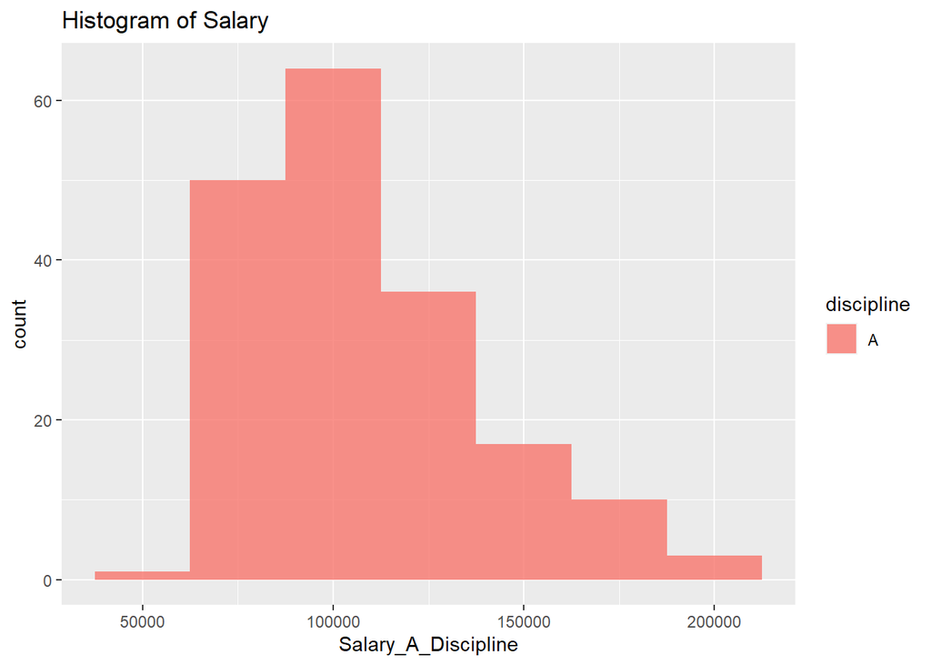

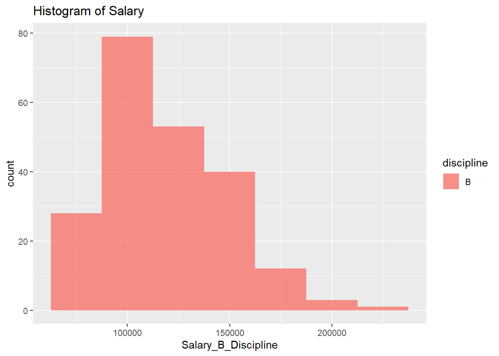

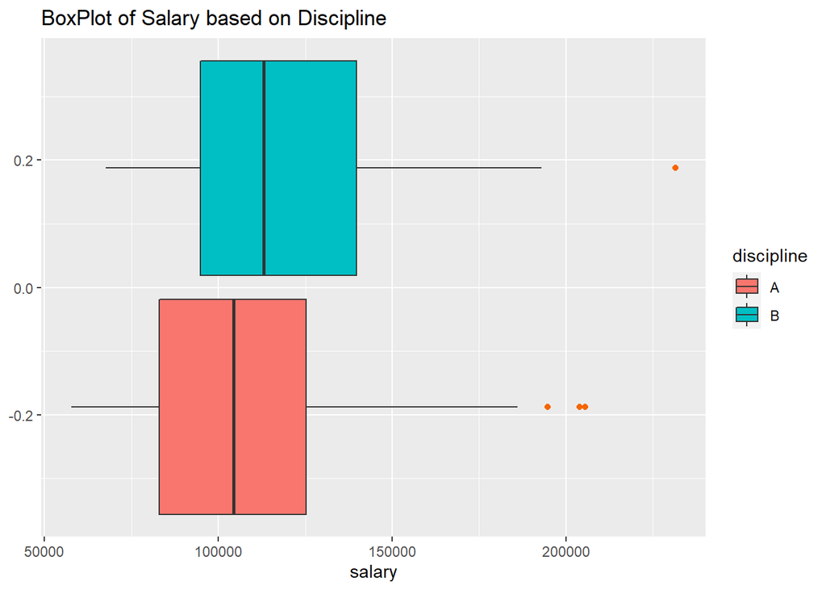

```r
# Data Visualization using ggplot() from tidyverse package

# Histogram
hist1A <- SalariesA %>%
  ggplot(mapping = aes(x = salary, fill = discipline))+
  geom_histogram(binwidth = 25000, alpha = 0.8)+
  labs(title = "Histogram of Salary", x = "Salary_A_Discipline")

hist1B <- SalariesB %>%
  ggplot(mapping = aes(x = salary, fill = discipline))+
  geom_histogram(binwidth = 25000, alpha = 0.8)+
  labs(title = "Histogram of Salary",  x = "Salary_B_Discipline")


#BoxPlot
bp1 <-  Salaries %>%
  ggplot(mapping = aes(x = salary, fill = discipline ))+
  geom_boxplot(outlier.color = "#F56600")+
  labs(title = "BoxPlot of Salary based on Discipline")

hist1A
hist1B
bp1
```

### Shapiro Wilk Test by discipline

```r
# This test is used to gain evidence that the sampling data is not normally distributed
# Shapiro_test() function is from rstatix package.

st1 <- Salaries %>%
  group_by(discipline) %>%
  shapiro_test(salary)
st1
```

| discipline | variable | statistic | p |
| --- | --- | --- | --- |
| A | salary | 0.9418299 | 1.026720e-06 |
| B | salary | 0.9611943 | 1.271009e-05 |

### qqPlot for Normality

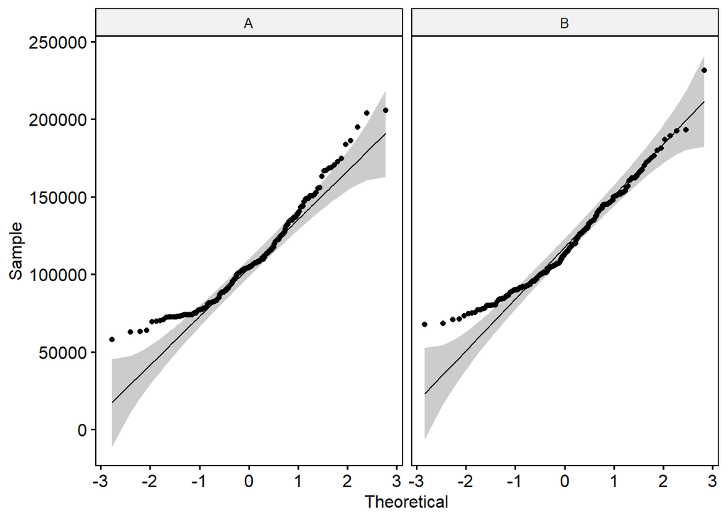

```r
# Finding normality of sample based on discipline using ggqqplot() function from ggpubr
ggqqplot(Salaries, x = "salary", facet.by = "discipline")
```

## **Inference** from Descriptive Statastics, Normality tests:

- From **Descriptive Statastics** we can see the mean sample salary of discipline__B__ is higher than that of discipline__A__.
- In **shapiro_test** P_Value is less than 0.05. Therfore, we can say that the sample is not normally distributed.
- From **qqplot**, we came to know that that the data is not normally distributed in a perfect manner.
- From **BoxPlot**, we can observe that there are some outliers.
- From the **histogram Plot**, we can observe that both the disciplines distributions are right skewed
- However, since the number of data points are high we can consider the sampling mean distribution as normal.

## Two Pair T_Test

```r
# Two pair hypothesis t_test using t_test() function from rstatix package.
test1 <- Salaries %>%
  t_test(salary ~ discipline) %>%
  add_significance()
test1
```

|  | .y. | group1 | group2 | n1 | n2 | statistic | df | p | p.signif |
| --- | --- | --- | --- | --- | --- | --- | --- | --- | --- |
| 1 | salary | A | B | 181 | 216 | -3.130634 | 377.8305 | 0.00188 | ** |

## Summary of the Hypothesis Test to find weather there is actual difference between the mean salaries of individuals based on descipline:

- A two-sample t-test was computed to determine whether the population mean salary of **TheoreticalDepartment(A)** differs from the Population mean salary of __AppliedDepartment(B).
- Since the P-Value for the two sample T-test is **<0.05** we are able to reject the hypothesis. And, we can state that **Applied deparment** have high salary than that of **theoretical Department**.

# Is there any difference in the mean salaries based on the gender?

## Hypothesis Test:

$$H_0: \mu_1 = \mu_2$$
$$H_A: \mu_1 \ne \mu_2$$

- **NOTE:**
  - MU1 is the Population mean salary of female gender
  - MU2 is the Population mean salary of male gender

## Assumptions:

- Random Sampling is done while collecting the sample

## Data Management For Hypothesis Testing:

```r
# Creating datasets based on gender using filter function from Tidyverse package.
SalariesM <- Salaries %>% filter(sex == "Male" )
SalariesF <- Salaries %>% filter(sex == "Female")
```

### Salaries based on Female gender

```r
head(SalariesF, 10)%>% knitr::kable()
```

| rank | discipline | yrs_service | sex | salary |
| --- | --- | --- | --- | --- |
| Prof | B | 18 | Female | 129000 |
| Prof | A | 36 | Female | 137000 |
| AssocProf | A | 8 | Female | 74830 |
| AsstProf | B | 2 | Female | 80225 |
| AsstProf | B | 0 | Female | 77000 |
| Prof | B | 19 | Female | 151768 |
| Prof | B | 25 | Female | 140096 |
| AsstProf | B | 3 | Female | 74692 |
| AssocProf | B | 11 | Female | 103613 |
| Prof | B | 17 | Female | 111512 |

### Salaries based on Male gender

```r
head(SalariesM, 10)%>% knitr::kable()
```

| rank | discipline | yrs_service | sex | salary |
| --- | --- | --- | --- | --- |
| Prof | B | 18 | Male | 139750 |
| Prof | B | 16 | Male | 173200 |
| AsstProf | B | 3 | Male | 79750 |
| Prof | B | 39 | Male | 115000 |
| Prof | B | 41 | Male | 141500 |
| AssocProf | B | 6 | Male | 97000 |
| Prof | B | 23 | Male | 175000 |
| Prof | B | 45 | Male | 147765 |
| Prof | B | 20 | Male | 119250 |
| AssocProf | B | 8 | Male | 119800 |

## Descriptive Statastics

```r
# Finding Means and Standard Deviations based on gender using group_by(), summarise() functions from Tidyverse package
Salaries %>%
  group_by(sex) %>%
  summarise(Mean_Salary = mean(salary, na.rm = TRUE),
            Sd_Salary = sd(salary, na.rm = TRUE),
            Count = n()
            )
```

| sex | Mean_Salary | Sd_Salary | Count |
| --- | --- | --- | --- |
| Female | 101002.4 | 25952.13 | 39 |
| Male | 115090.4 | 30436.93 | 358 |

## Tests For Normality

### Finding the shape of **Histogram** and outliers from **BoxPlot**

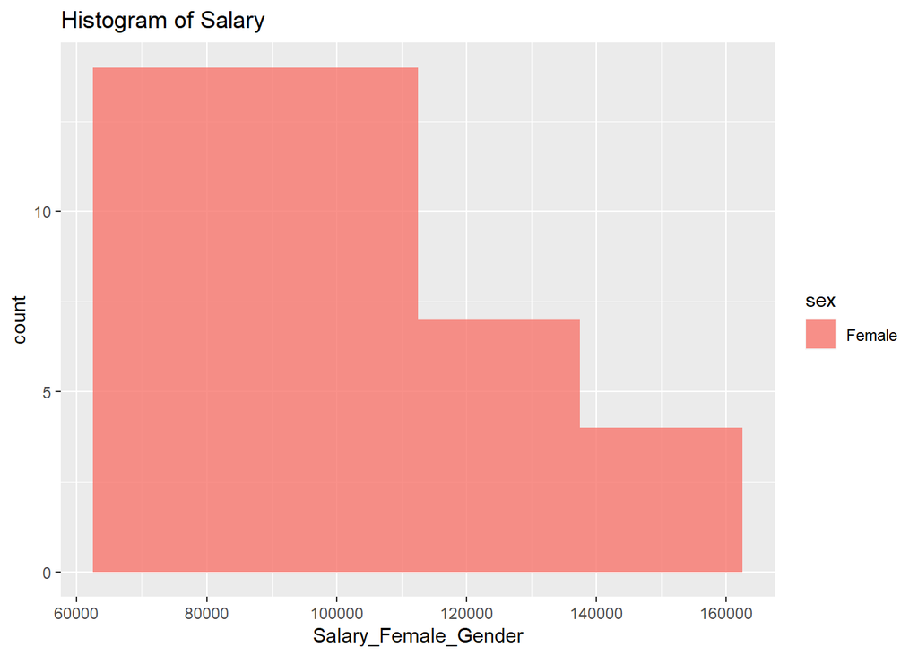

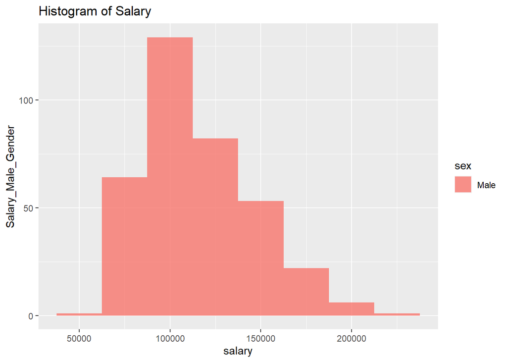

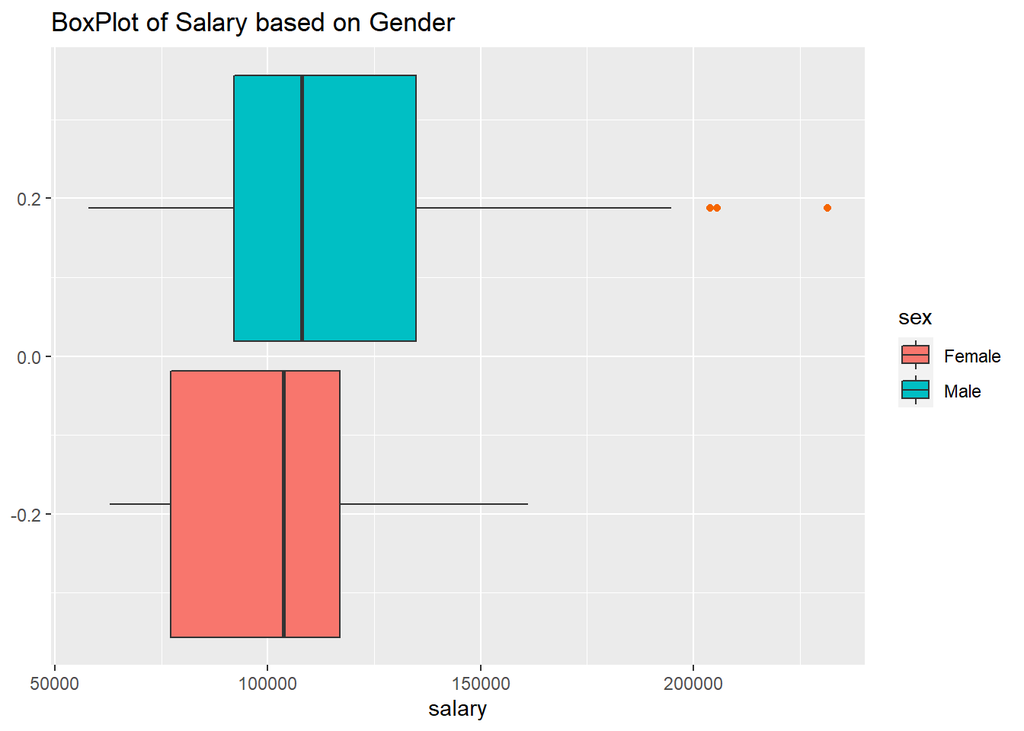

```r
# Data Visualization Using ggplot from tidyverse package


# Histogram
hist2A <- SalariesF %>%
  ggplot(mapping = aes(x = salary, fill = sex))+
  geom_histogram(binwidth=25000, alpha = 0.8)+
  labs(title = "Histogram of Salary", x= "Salary_Female_Gender")


hist2B <- SalariesM %>%
  ggplot(mapping = aes(x = salary, fill = sex))+
  geom_histogram(binwidth=25000, alpha = 0.8)+
  labs(title = "Histogram of Salary", y= "Salary_Male_Gender")

# BoxPlot
bp2 <-  Salaries %>%
  ggplot(mapping = aes(x = salary, fill = sex))+
  geom_boxplot(outlier.color = "#F56600")+
  labs(title = "BoxPlot of Salary based on Gender")

hist2A
hist2B
bp2
```

### Shapiro Wilk Test by discipline

```r
# This test is used to gain evidence that the sampling data is not normally distributed
# Using shapiro_test() function from rstatix package
st2 <- Salaries %>%
  group_by(sex) %>%
  shapiro_test(salary)
st2
```

| sex | variable | statistic | p |
| --- | --- | --- | --- |
| Female | salary | 0.9466484 | 6.338937e-02 |
| Male | salary | 0.9587671 | 1.734666e-08 |

### qqPlot for Normality

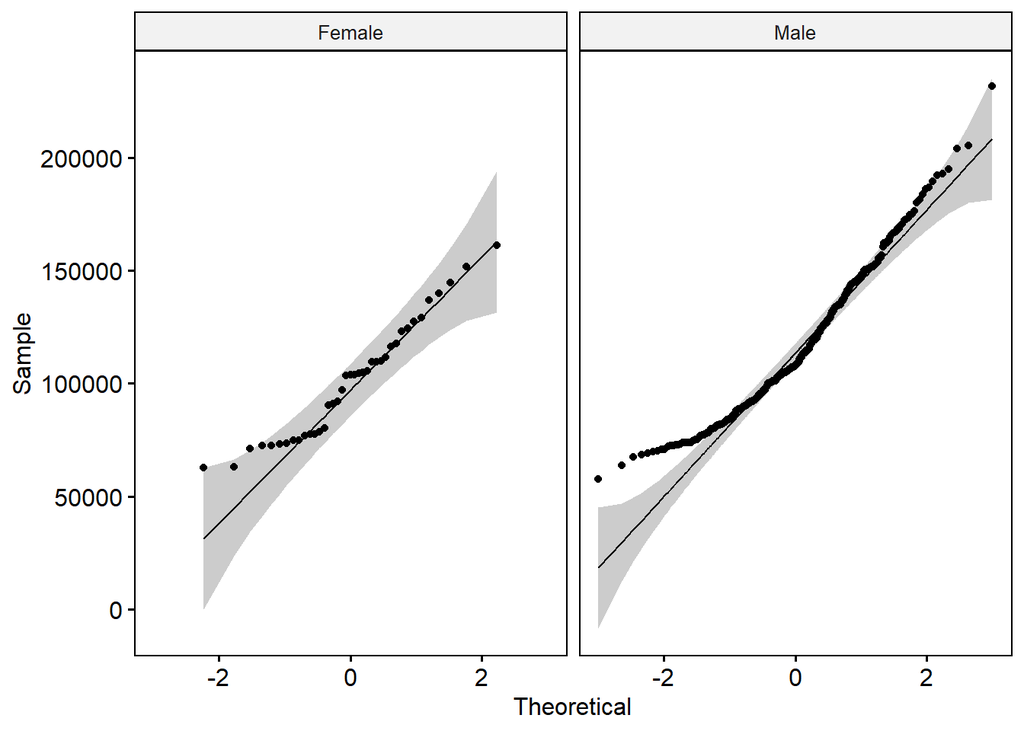

```r
# Normality check using ggqqplot from ggpubr package
ggqqplot(Salaries, x = "salary", facet.by = "sex")
```

## Performing Two Pair T_Test:

```r
# Two pair hypothesis t_test using t_test() function from rstatix package.
test2 <- Salaries %>%
  t_test(salary ~ sex) %>%
  add_significance()
test2
```

|  | .y. | group1 | group2 | n1 | n2 | statistic | df | p | p.signif |
| --- | --- | --- | --- | --- | --- | --- | --- | --- | --- |
| 1 | salary | Female | Male | 39 | 358 | -3.161474 | 50.12152 | 0.00266 | ** |

## Summary of the Hypothesis Test to find weather there is actual difference between the mean salaries of individuals based on Gender:

- A two-sample t-test was computed to determine whether the population mean salary of **female** gender differs from the Population mean salary of **male** gender.
- Since the P-Value for the two sample T-test is **<0.05** we are able to reject the hypothesis. And, we can state that **female gender** have low mean salary than **male gender**.

# Inference from both the hypothesis testings

- We came to know that mean salaries are different for categorical variables, discipline and gender, respectively. Therefore, if we want to build a multiple linear regression model both of these categorical variables plays an important roll in estimating **salaries**, which is going to be our response variable.

# Linear regession for **salary**

## Data Set for the first linear regression

```r
# Interactive table using datatable() function from DT package.

datatable(head(Salaries, 20),
          rownames = FALSE,
          extensions = 'Scroller',
          filter = 'bottom')
```

| rank | discipline | yrs_service | sex | salary |
| --- | --- | --- | --- | --- |
| Prof | B | 18 | Male | 139750 |
| Prof | B | 16 | Male | 173200 |
| AsstProf | B | 3 | Male | 79750 |
| Prof | B | 39 | Male | 115000 |
| Prof | B | 41 | Male | 141500 |
| AssocProf | B | 6 | Male | 97000 |
| Prof | B | 23 | Male | 175000 |
| Prof | B | 45 | Male | 147765 |
| Prof | B | 20 | Male | 119250 |
| Prof | B | 18 | Female | 129000 |

[output cut: 10 more lines]

## Response Variable Vs Explonatory Variables Graphs:

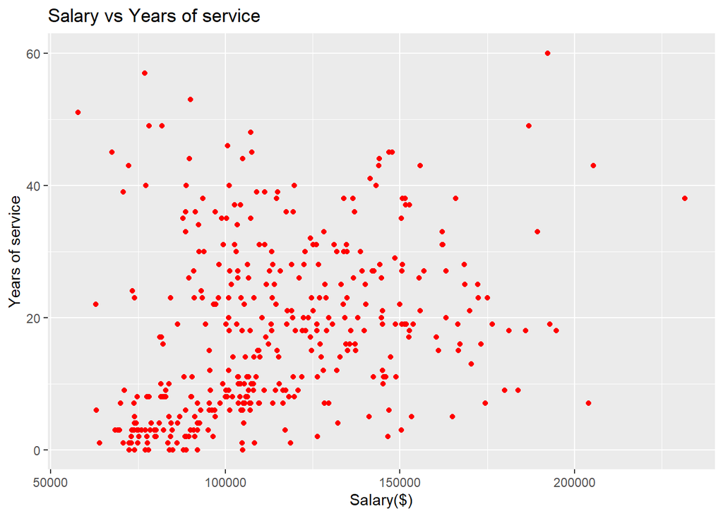

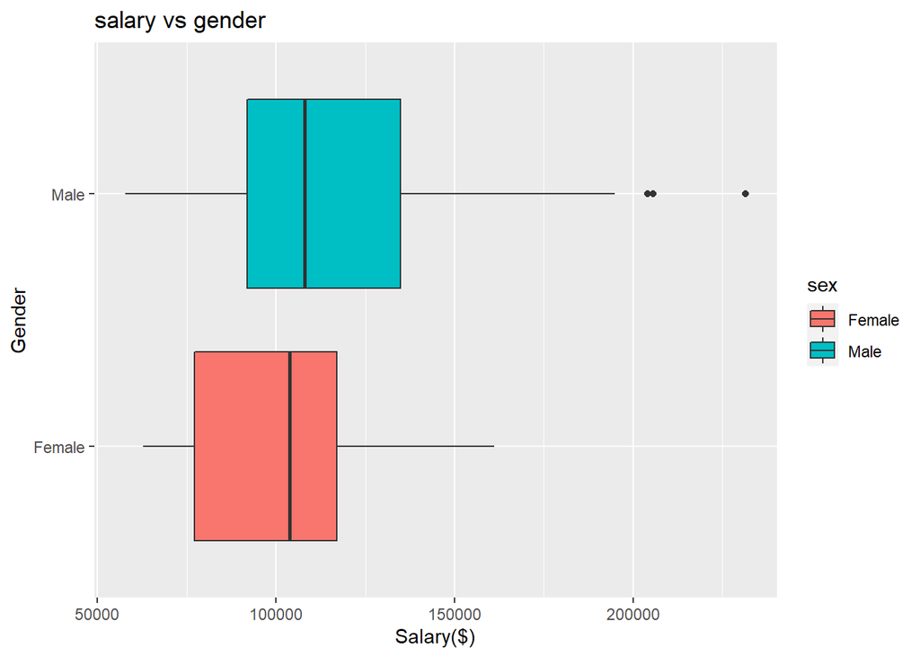

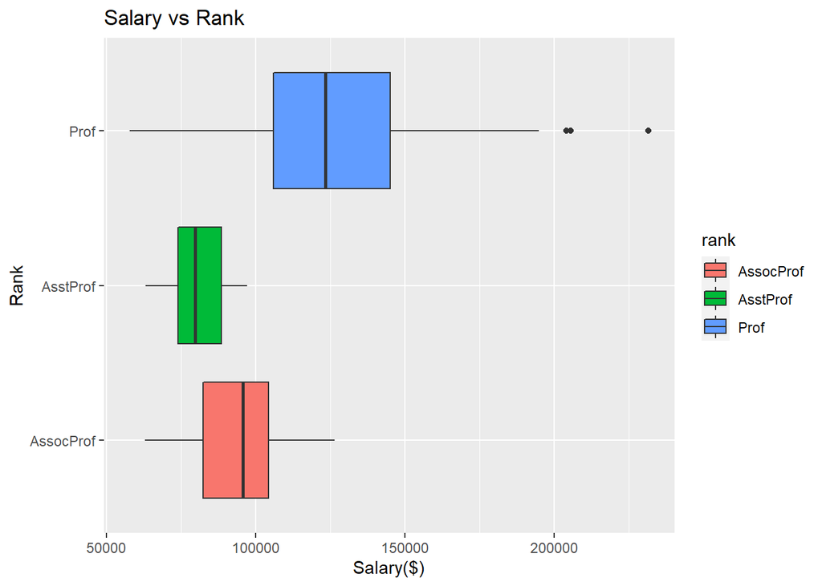

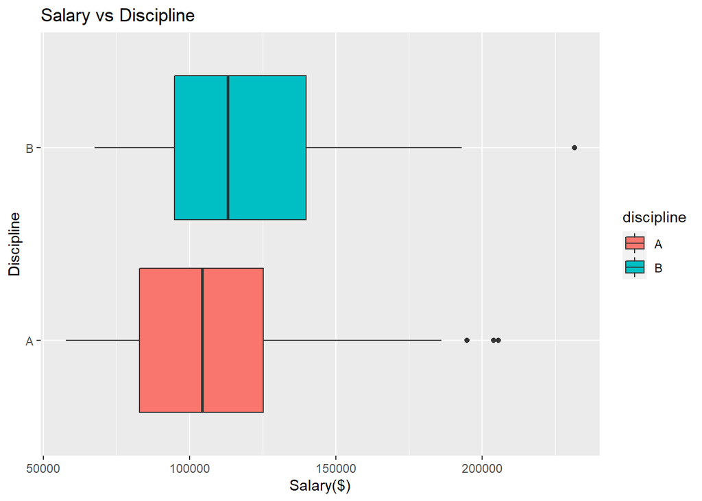

```r
# Data Visualization based on response variable(salary) vs explanatory variable(yrs_service, sex, rank, discipline) using ggplot() function from tidyverse package/suit

plot1 <- ggplot(Salaries, aes(x = salary, y = yrs_service))+geom_point(color = "red") +
  labs(title = "Salary vs Years of service", x = "Salary($)", y = "Years of service")

plot2 <- ggplot(Salaries, aes(x = salary, y = sex, fill= sex))+geom_boxplot()+
  labs(title = "salary vs gender", x = "Salary($)", y = "Gender")

plot3 <- ggplot(Salaries, aes(x = salary, y = rank, fill = rank))+geom_boxplot()+
  labs(title = "Salary vs Rank ", x = "Salary($)", y = "Rank")

plot4 <- ggplot(Salaries, aes(x = salary, y = discipline, fill = discipline))+geom_boxplot()+
  labs(title = "Salary vs Discipline", x = "Salary($)", y = "Discipline")


plot1
plot2
plot3
plot4
```

## Inference from the graphs:

- From **Salary vs Years of Service** graph, we can not able specify that there is exact linear relation ship between those two variables it is because as the number of years of service increases more scattering of salary is present.
- From __ Salary vs Gender__ boxplot graph, we can see that the median salary of male is slightly greate than that of female.
- From **Salary vs Rank** boxplot graph, we can observe that the median salary of Professor rank holder is high, then the Associate Professor, and lastly the Asst Professor.
- From **Salary vs Discipline** boxplot graph, we can observe that the median salary of discipline B(Applied) is greater than that of discipline A(Theoretical).
- From these graphs we can say that **years_service** will not have a great contribution in finding salaries of faculty using linear regression model when compared to other variables it is because as the number of years of service increases more scattering of salary is present.

## Data Transformation

- Converting categorical variables in to numerical variables because this conversion will help us to find correlation across explanatory variables

```r
# Using Case_when(), mutate() functions in tidyverse package/suit we can change the values of the data which are present in dataframe/ tibble as follows

# I converted the categorical variables in to numerical values to calculate the correlation among the variables.
Salaries <- Salaries %>%
  mutate(rank = case_when(
    rank == "Prof"      ~ "1",
    rank == "AssocProf" ~ "2",
    rank == "AsstProf"  ~ "3",
    TRUE                ~  as.character(rank)
    ),
    discipline = case_when(
      discipline == "A" ~ "1",
      discipline == "B" ~ "2",
      TRUE              ~ as.character(discipline)
    ),
    sex = case_when(
      sex == "Female" ~ "1",
      sex == "Male"   ~ "2",
      TRUE            ~ as.character(sex)
    ),
    rank =as.numeric(rank),
    discipline = as.numeric(discipline),
    sex = as.numeric(sex)
    )

# Interactive data using datatable() function from DT package
datatable(head(Salaries, 20),
          rownames = FALSE,
          extensions = 'Scroller',
          filter = 'bottom')
```

| rank | discipline | yrs_service | sex | salary |
| --- | --- | --- | --- | --- |
| 1 | 2 | 18 | 2 | 139750 |
| 1 | 2 | 16 | 2 | 173200 |
| 3 | 2 | 3 | 2 | 79750 |
| 1 | 2 | 39 | 2 | 115000 |
| 1 | 2 | 41 | 2 | 141500 |
| 2 | 2 | 6 | 2 | 97000 |
| 1 | 2 | 23 | 2 | 175000 |
| 1 | 2 | 45 | 2 | 147765 |
| 1 | 2 | 20 | 2 | 119250 |
| 1 | 2 | 18 | 1 | 129000 |

[output cut: 10 more lines]

## Model Selection

### Forward Selection

```r
# creating a linear regression equation using lm() function from base R
lm <- lm(salary~., data = Salaries)

# Model selection using regsubset() function from leaps package
forward <- regsubsets(salary~., data = Salaries, method = "forward")

# summary is from base R package. Produces result summaries of various model fittings
summary(forward)
```

```
## Subset selection object
## Call: regsubsets.formula(salary ~ ., data = Salaries, method = "forward")
## 4 Variables  (and intercept)
##             Forced in Forced out
## rank            FALSE      FALSE
## discipline      FALSE      FALSE
## yrs_service     FALSE      FALSE
## sex             FALSE      FALSE
## 1 subsets of each size up to 4
## Selection Algorithm: forward
##          rank discipline yrs_service sex
## 1  ( 1 ) "*"  " "        " "         " "
## 2  ( 1 ) "*"  "*"        " "         " "
## 3  ( 1 ) "*"  "*"        " "         "*"
## 4  ( 1 ) "*"  "*"        "*"         "*"
```

### ForwardSelection Adjusted R^2 Plot

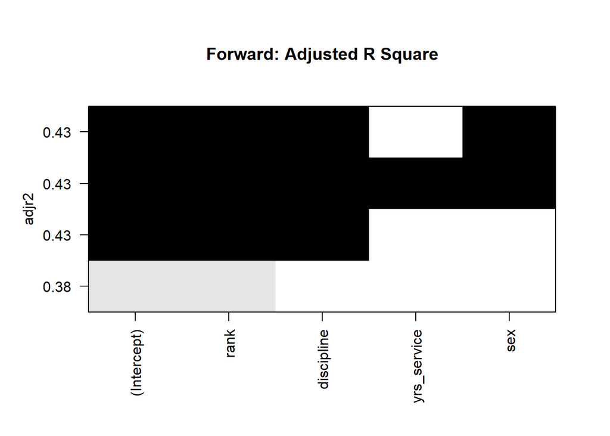

```r
plot(forward, scale="adjr2", main="Forward: Adjusted R Square")
```

- From this plot, we can observe that the adjusted R^2 is high when we take rank, discipline, and sex as the explanatory variables for creating linear regression eqaution

### Backward Elimination

```r
# Model selection using regsubset() function from leaps package
backward <- regsubsets(salary~., data = Salaries, method = "backward")

# summary is from base R package. Produces result summaries of various model fittings
summary(backward)
```

```
## Subset selection object
## Call: regsubsets.formula(salary ~ ., data = Salaries, method = "backward")
## 4 Variables  (and intercept)
##             Forced in Forced out
## rank            FALSE      FALSE
## discipline      FALSE      FALSE
## yrs_service     FALSE      FALSE
## sex             FALSE      FALSE
## 1 subsets of each size up to 4
## Selection Algorithm: backward
##          rank discipline yrs_service sex
## 1  ( 1 ) "*"  " "        " "         " "
## 2  ( 1 ) "*"  "*"        " "         " "
## 3  ( 1 ) "*"  "*"        " "         "*"
## 4  ( 1 ) "*"  "*"        "*"         "*"
```

### BackwardElimination Adjusted R^2 Plot

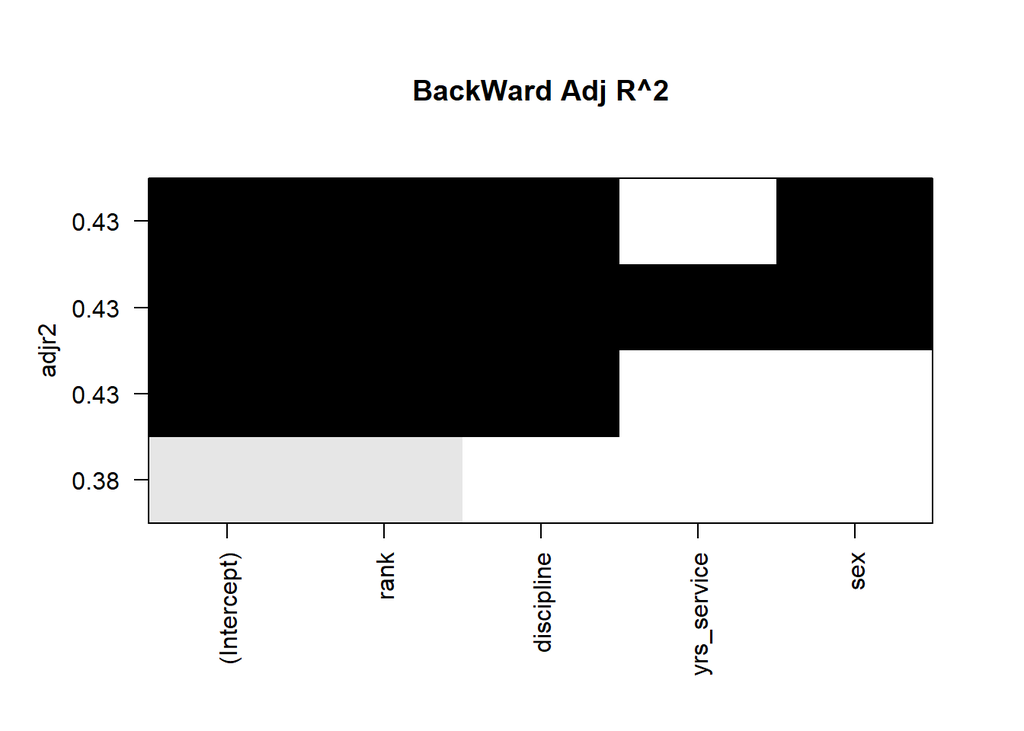

```r
plot(backward, scale = "adjr2", main = "BackWard Adj R^2")
```

* From this plot, we can observe that the adjusted R^2 is high when we take rank, discipline, and sex as the explanatory variables for creating linear regression equation

### Sequential Replacement

```r
# Model selection using regsubset() function from leaps package
seq <- regsubsets(salary~., data = Salaries, method = "seqrep")

# summary is from base R package. Produces result summaries of various model fittings
summary(seq)
```

```
## Subset selection object
## Call: regsubsets.formula(salary ~ ., data = Salaries, method = "seqrep")
## 4 Variables  (and intercept)
##             Forced in Forced out
## rank            FALSE      FALSE
## discipline      FALSE      FALSE
## yrs_service     FALSE      FALSE
## sex             FALSE      FALSE
## 1 subsets of each size up to 4
## Selection Algorithm: 'sequential replacement'
##          rank discipline yrs_service sex
## 1  ( 1 ) "*"  " "        " "         " "
## 2  ( 1 ) "*"  "*"        " "         " "
## 3  ( 1 ) "*"  "*"        " "         "*"
## 4  ( 1 ) "*"  "*"        "*"         "*"
```

### Sequential Replacement Adjusted R^2 Plot

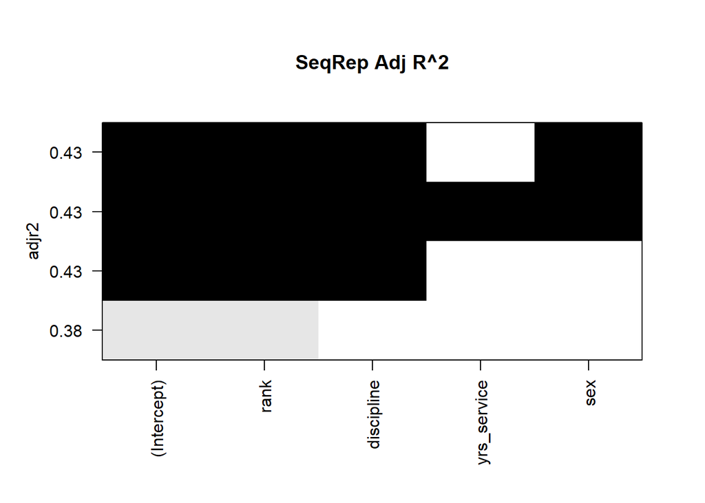

```r
plot(seq, scale = "adjr2", main = "SeqRep Adj R^2")
```

* From this plot, we can observe that the adjusted R^2 is high when we take rank, discipline, and sex as the explanatory variables for creating linear regression eqaution

### Bet_fit

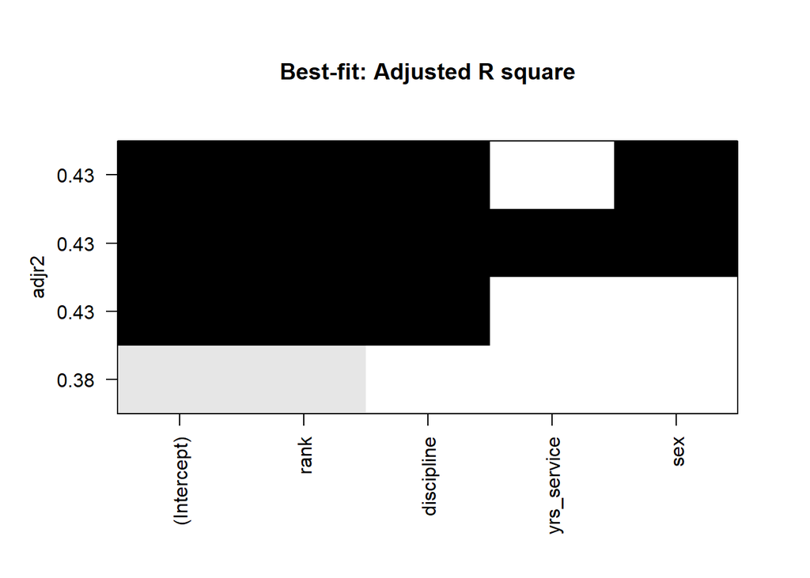

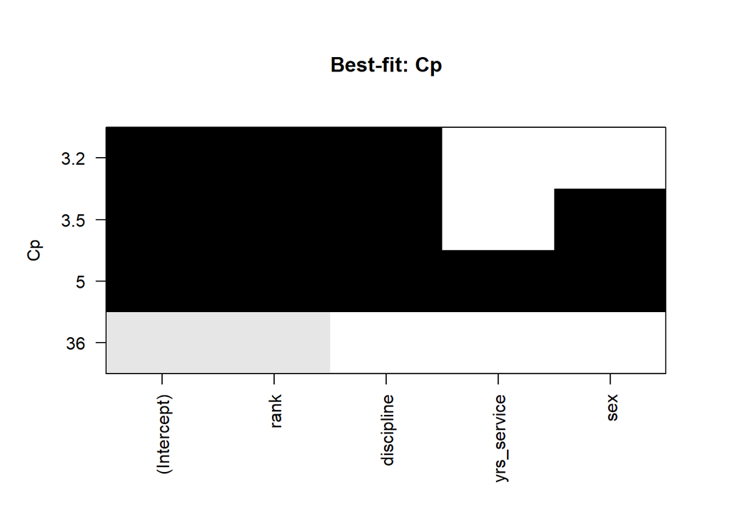

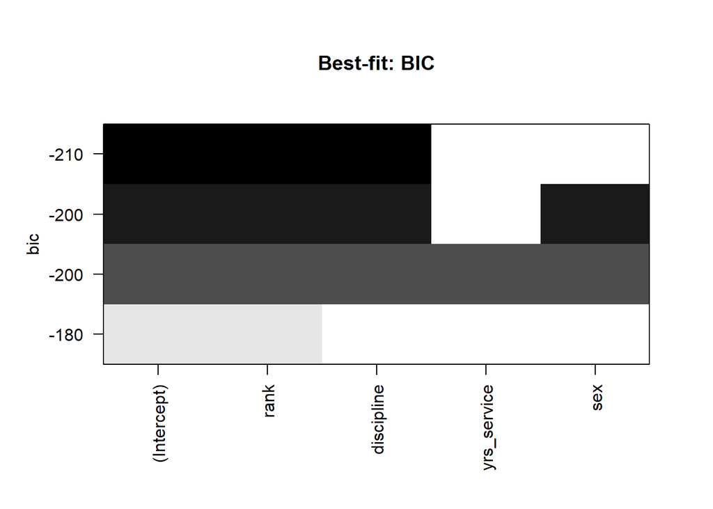

```r
# Model selection using regsubset() function from leaps package
best <- regsubsets(salary~., data=Salaries)

plot(best, scale="adjr2", main="Best-fit: Adjusted R square")
plot(best, scale="Cp", main="Best-fit: Cp")
plot(best, scale="bic", main="Best-fit: BIC")
```

## Summary of BestFit

```r
# summary is from base R package. Produces result summaries of various model fittings
best.sum<- summary(best)

# Creating a data frame that can shows the best fit by model.
out.table <- data.frame(best.sum$outmat, best.sum$adjr2, best.sum$rss, best.sum$cp, best.sum$bic)
out.table
```

|  | rank | discipline | yrs_service | sex | best.sum.adjr2 | best.sum.rss | best.sum.cp | best.sum.bic |
| --- | --- | --- | --- | --- | --- | --- | --- | --- |
| 1 ( 1 ) | * |  |  |  | 0.3793986 | 224895529548 | 35.887635 | -178.4312 |
| 2 ( 1 ) | * | * |  |  | 0.4280943 | 206724343453 | 3.234225 | -205.8944 |
| 3 ( 1 ) | * | * |  | * | 0.4290972 | 205838066204 | 3.544048 | -201.6162 |
| 4 ( 1 ) | * | * | * | * | 0.4284341 | 205552784239 | 5.000000 | -196.1829 |

- Model Selection

I choose model 3 - with rank, discipline, sex . This model has the largest adjusted r^2 value, one of smallest values for sum of rss,one of the smallest Cp value, and one of the smallest BIC values. In addition, this is the model that was chosen by Forward selection, Backward elimination and Sequential Replacement methods.

## Doing Multiple Regression with the selected model **Three**

```r
# Creating a linear regression equation based on the chosen model three
chosen.lm <- lm(salary~rank+discipline+sex, data = Salaries)

# get_regression_table is from the moderndive package
chosen.table <- get_regression_table(chosen.lm, digits = 15)

# prints the intercept, and coefficients of explanatory variables of linear regression equation.
chosen.lm
```

```
##
## Call:
## lm(formula = salary ~ rank + discipline + sex, data = Salaries)
##
## Coefficients:
## (Intercept)         rank   discipline          sex
##      120579       -25036        13606         5070
```

## Check assumptions

- Assumption 1: the probability distribution of the random errors (ϵ) has a mean of 0.
- Assumption 2: the probability distribution of the random errors (ϵ) has a constant variance
- Assumption 3: the probability distribution of the random errors (ϵ) follows a normal distribution
- Assumption 4: the random errors (ϵ) are independent
- Assumption 5: Little to no multicollinearity

## **Assumption 1** : errors have a mean of zero - assume it is true

## **Assumption 2**: errors have a constant variance

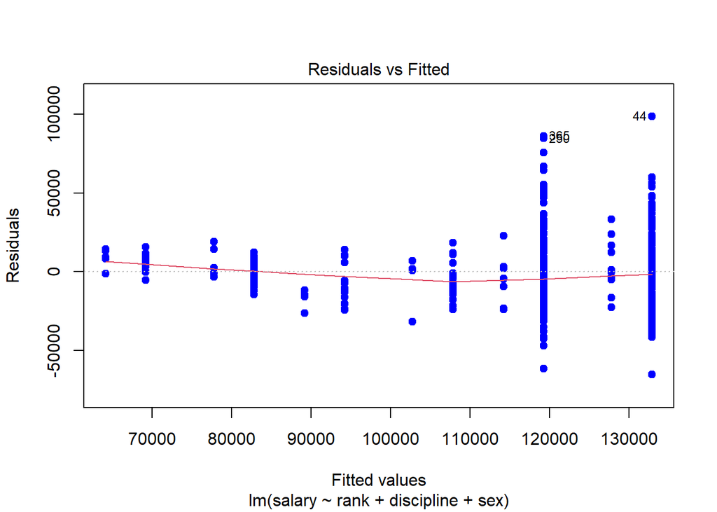

```r
# Checking weather the residuals(errors) have constant variance or not by using residuals vs fitted plot.
plot(chosen.lm, 1, col="blue", pch=19)
```

- From the **Residuals vs Fitted** graph, we can see that the residuals are following some pattern along the fitted values, therefore, we can interpret that the variance of residuals are not constant.

```r
#NCV TEST is a hypothesis test to find weather residual's variances are constant or not
NCV <- ncvTest(chosen.lm)
NCV
```

```
## Non-constant Variance Score Test
## Variance formula: ~fitted.values
## Chisquare = 46.05509, Df = 1, p = 1.1497e-11
```

- Since the P-Value(~ 0 ) is **< 0.05** we are able reject the null hypothesis. Therefore, There is sufficient evidence to suggest that there is not constant variance for the residuals of linear regression model.

## **Assumption 3**: errors are normally distributed - The normal probability plot shows a linear pattern.

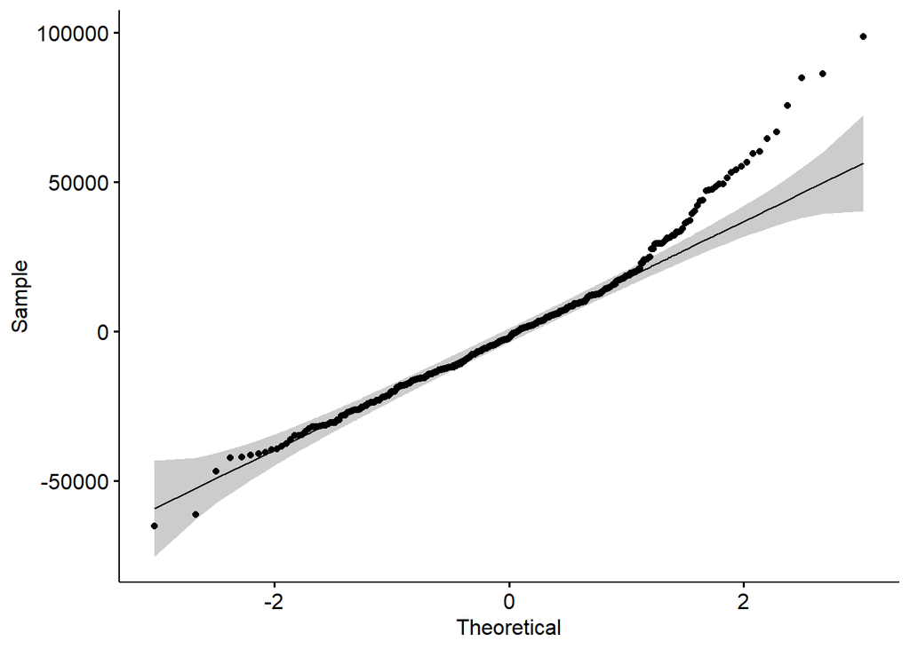

```r
# ggqqplot is from ggpubr package to test the normality of residuals.
ggqqplot(residuals(chosen.lm))
```

- **Note:** from the qqplot, we see that error (residual) distribution is slightly right skewed.

## **Assumption 4**: Random errors are independent (no autocorrelation)

- One way to test this is the Durbin-Watson d test. Durbin-Watson’s d test tests the null hypothesis that the residuals are not linearly auto-correlated. While “d” can assume values between 0 and 4, values around 2 indicate no autocorrelation. As a rule of thumb values of 1.5 < d < 2.5 show that there is no auto-correlation in the data.

```r
# Durbin Watson test for independence(No AutoCorrelation)

# dwt() function is from car package
dwt <- durbinWatsonTest(chosen.lm)
dwt
```

```
##  lag Autocorrelation D-W Statistic p-value
##    1       0.0658997      1.867294   0.166
##  Alternative hypothesis: rho != 0
```

- the Durbin Watson test has a p-value greater than any reasonable alpha level(0.05). There is sufficient evidence to suggest that there is no autocorrelation.

## **Assumption 5:** no multicollinearity

```r
# In order to have correlation matrix, we need the categorical data must be in numbers
COR <- cor(Salaries[,c(1, 2, 4, 5)])
COR %>% knitr::kable()
```

|  | rank | discipline | sex | salary |
| --- | --- | --- | --- | --- |
| rank | 1.0000000 | 0.1073645 | -0.1385557 | -0.6172243 |
| discipline | 0.1073645 | 1.0000000 | 0.0037237 | 0.1560839 |
| sex | -0.1385557 | 0.0037237 | 1.0000000 | 0.1386102 |
| salary | -0.6172243 | 0.1560839 | 0.1386102 | 1.0000000 |

- **Note:** From above table, we can say that the explanatory variables are not correlated because none of them have the correlation > 0.8 or < -0.8.

### Using the VIF Test also we can check **Multicollinearity**

```r
#vif is From Cars Package  check
vif(chosen.lm) %>% knitr::kable()
```

|  | x |
| --- | --- |
| rank | 1.031817 |
| discipline | 1.012023 |
| sex | 1.019937 |

- **Note:** From VIF test we can observe that the VIF values of Explanatory variables are not greater than 5. Therefore, this test is not indicating any sort of multicollinearity.

## Model Evaluation

```r
# get_regression_summaries() is from moderndive package used to print summary statastics for lm() regression in a clean format
Salaries.sum <-  get_regression_summaries(chosen.lm, digits=20)
Salaries.sum %>% knitr::kable()
```

| r_squared | adj_r_squared | mse | rmse | sigma | statistic | p_value | df | nobs |
| --- | --- | --- | --- | --- | --- | --- | --- | --- |
| 0.4334222 | 0.4290972 | 518483794 | 22770.24 | 22885.82 | 100.2127 | 0 | 3 | 397 |

- For our example, the p-value is 0, this is smaller than any reasonable significant alpha level. There is sufficient evidence to suggest that the overall model using rank, discipline, and sex to predict salary explains a significant amount of the variation.

## Evaluation of the usefulness of the Model

```r
#get_regression_table is from the moderndive package, which is used in creating chosen.table.

# this table gives the statastic summary of the regression coefficients and intercepts.
chosen.table %>% knitr::kable()
```

| term | estimate | std_error | statistic | p_value | lower_ci | upper_ci |
| --- | --- | --- | --- | --- | --- | --- |
| intercept | 120578.594 | 8731.329 | 13.809879 | 0.0000000 | 103412.639 | 137744.55 |
| rank | -25035.764 | 1522.151 | -16.447623 | 0.0000000 | -28028.341 | -22043.19 |
| discipline | 13605.749 | 2320.015 | 5.864509 | 0.0000000 | 9044.556 | 18166.94 |
| sex | 5069.825 | 3897.398 | 1.300823 | 0.1940812 | -2592.532 | 12732.18 |

- Except for the explainatory variable, sex,all the **P-values are <= 0.05**. Since the majority of explainatory varibles have less p value, we can conclude that there is enough evidence that the linear model is useful in predicting the price.

# Using Our Created Model for Prediction:

- **Regression_Equation** :
  - **salary** = 120578.594 - 25035.764* **Rank** + 13605.75* **discipline** + 5069.825* **sex**
- Predicting salary for rank = “Prof”, sex = “Male”, discipline = “A”

```r
# Creating a dataframe
new <- data.frame(rank = 1, sex = 2, discipline = 1)

#predict is a generic function for predictions from the results of various model fitting functions, which is from stats package
prediction <- predict(chosen.lm, newdata = new, interval = "confidence")
prediction %>% knitr::kable()
```

| fit | lwr | upr |
| --- | --- | --- |
| 119288.2 | 115682.4 | 122894 |

- We are 95% confident that the values are in the given above range

# References

Fox J. and Weisberg, S. (2019) An R Companion to Applied Regression, Third Edition, Sage.

# About MySelf

- My name is Koganti, Venkata Rama Sri Harsha. I am a full time graduate student in Industrial Engineering at Clemson University. I have done my under graduation in Mechanical Engineering back in my home country India at Mahindra Ecole Centrale, an university which is established under the collaboration of Mahindra and Mahindra(AutoMobile Company) and Ecole Centrale of Paris. I am Interested in systems modeling, which is a sub branch of Industrial engineering where we need to create process flow for different systems in a logical manner by using Arena Sofware.

# Apendix

- Please click on the `code` button towards your right to see the overall code

```r
library(ggpubr)     # to draw ggqqplots through which we can find the normality of sample data set
library(tidyverse)  # For data wrangling, piping, datavisulization.
library(qqplotr)
library(rstatix)    # Pipe Friendliy R-Functions for statistical analyses.
library(gridExtra)  # For arranging the plots
library(car)        # for durbin watson test
library(leaps)      # For selecting Regression Model
library(moderndive) #Datasets and wrapper functions for tidyverse-friendly introductory linear regression
library(DT)         # For Interactive data sets
library(prettydoc)  # For Rmarkdown themes
# reading data from csv file
# cleaning the data usinf clean_names() function from janitor package
Salaries <- read_csv("Salaries.csv") %>% janitor::clean_names()
# Printing Interactive datatable from DT package.
datatable(head(Salaries, 100),
          rownames = FALSE,
          extensions = 'Scroller',
          filter = 'bottom')

# To find correlation
Correlation1 <- cor(Salaries[,c(4, 5)])

# Printing the results of correlation table in a nice form using kable() function from knitr package

Correlation1 %>% knitr::kable()




# For selecting required data variables using select() function from tidyverse package
Salaries <- Salaries %>%
  select(rank, discipline, yrs_service, sex, salary)

# Printing Data Table in an  interactive manner using datatable function from "DT" package.
datatable(head(Salaries, 20),
          rownames = FALSE,
          extensions = 'Scroller',
          filter = 'bottom')


# Creating datasets based on discipline using filter function from Tidyverse package.
SalariesA <- Salaries %>% filter(discipline == "A" )
SalariesB <- Salaries %>% filter(discipline == "B")

head(SalariesA, 10)%>% knitr::kable()
head(SalariesB, 10)%>% knitr::kable()
# Finding Means and Standard Deviations based on discipline using group_by(), summarise functions from Tidyverse package
Salaries %>%
  group_by(discipline) %>%
  summarise(Mean_Salary = mean(salary, na.rm = TRUE),
            Sd_Salary = sd(salary, na.rm = TRUE),
            Count = n()
            )%>% knitr::kable()
# Data Visualization using ggplot() from tidyverse package

# Histogram
hist1A <- SalariesA %>%
  ggplot(mapping = aes(x = salary, fill = discipline))+
  geom_histogram(binwidth = 25000, alpha = 0.8)+
  labs(title = "Histogram of Salary", x = "Salary_A_Discipline")

hist1B <- SalariesB %>%
  ggplot(mapping = aes(x = salary, fill = discipline))+
  geom_histogram(binwidth = 25000, alpha = 0.8)+
  labs(title = "Histogram of Salary",  x = "Salary_B_Discipline")


#BoxPlot
bp1 <-  Salaries %>%
  ggplot(mapping = aes(x = salary, fill = discipline ))+
  geom_boxplot(outlier.color = "#F56600")+
  labs(title = "BoxPlot of Salary based on Discipline")

hist1A
hist1B
bp1



# This test is used to gain evidence that the sampling data is not normally distributed
# Shapiro_test() function is from rstatix package.

st1 <- Salaries %>%
  group_by(discipline) %>%
  shapiro_test(salary)
st1
# Finding normality of sample based on discipline using ggqqplot() function from ggpubr
ggqqplot(Salaries, x = "salary", facet.by = "discipline")

# Two pair hypothesis t_test using t_test() function from rstatix package.
test1 <- Salaries %>%
  t_test(salary ~ discipline) %>%
  add_significance()
test1

# Creating datasets based on gender using filter function from Tidyverse package.
SalariesM <- Salaries %>% filter(sex == "Male" )
SalariesF <- Salaries %>% filter(sex == "Female")
head(SalariesF, 10)%>% knitr::kable()
head(SalariesM, 10)%>% knitr::kable()
# Finding Means and Standard Deviations based on gender using group_by(), summarise() functions from Tidyverse package
Salaries %>%
  group_by(sex) %>%
  summarise(Mean_Salary = mean(salary, na.rm = TRUE),
            Sd_Salary = sd(salary, na.rm = TRUE),
            Count = n()
            )

# Data Visualization Using ggplot from tidyverse package


# Histogram
hist2A <- SalariesF %>%
  ggplot(mapping = aes(x = salary, fill = sex))+
  geom_histogram(binwidth=25000, alpha = 0.8)+
  labs(title = "Histogram of Salary", x= "Salary_Female_Gender")


hist2B <- SalariesM %>%
  ggplot(mapping = aes(x = salary, fill = sex))+
  geom_histogram(binwidth=25000, alpha = 0.8)+
  labs(title = "Histogram of Salary", y= "Salary_Male_Gender")

# BoxPlot
bp2 <-  Salaries %>%
  ggplot(mapping = aes(x = salary, fill = sex))+
  geom_boxplot(outlier.color = "#F56600")+
  labs(title = "BoxPlot of Salary based on Gender")

hist2A
hist2B
bp2


# This test is used to gain evidence that the sampling data is not normally distributed
# Using shapiro_test() function from rstatix package
st2 <- Salaries %>%
  group_by(sex) %>%
  shapiro_test(salary)
st2
# Normality check using ggqqplot from ggpubr package
ggqqplot(Salaries, x = "salary", facet.by = "sex")
# Two pair hypothesis t_test using t_test() function from rstatix package.
test2 <- Salaries %>%
  t_test(salary ~ sex) %>%
  add_significance()
test2

# Interactive table using datatable() function from DT package.

datatable(head(Salaries, 20),
          rownames = FALSE,
          extensions = 'Scroller',
          filter = 'bottom')

# Data Visualization based on response variable(salary) vs explanatory variable(yrs_service, sex, rank, discipline) using ggplot() function from tidyverse package/suit

plot1 <- ggplot(Salaries, aes(x = salary, y = yrs_service))+geom_point(color = "red") +
  labs(title = "Salary vs Years of service", x = "Salary($)", y = "Years of service")

plot2 <- ggplot(Salaries, aes(x = salary, y = sex, fill= sex))+geom_boxplot()+
  labs(title = "salary vs gender", x = "Salary($)", y = "Gender")

plot3 <- ggplot(Salaries, aes(x = salary, y = rank, fill = rank))+geom_boxplot()+
  labs(title = "Salary vs Rank ", x = "Salary($)", y = "Rank")

plot4 <- ggplot(Salaries, aes(x = salary, y = discipline, fill = discipline))+geom_boxplot()+
  labs(title = "Salary vs Discipline", x = "Salary($)", y = "Discipline")


plot1
plot2
plot3
plot4


# Using Case_when(), mutate() functions in tidyverse package/suit we can change the values of the data which are present in dataframe/ tibble as follows

# I converted the categorical variables in to numerical values to calculate the correlation among the variables.
Salaries <- Salaries %>%
  mutate(rank = case_when(
    rank == "Prof"      ~ "1",
    rank == "AssocProf" ~ "2",
    rank == "AsstProf"  ~ "3",
    TRUE                ~  as.character(rank)
    ),
    discipline = case_when(
      discipline == "A" ~ "1",
      discipline == "B" ~ "2",
      TRUE              ~ as.character(discipline)
    ),
    sex = case_when(
      sex == "Female" ~ "1",
      sex == "Male"   ~ "2",
      TRUE            ~ as.character(sex)
    ),
    rank =as.numeric(rank),
    discipline = as.numeric(discipline),
    sex = as.numeric(sex)
    )

# Interactive data using datatable() function from DT package
datatable(head(Salaries, 20),
          rownames = FALSE,
          extensions = 'Scroller',
          filter = 'bottom')

# creating a linear regression equation using lm() function from base R
lm <- lm(salary~., data = Salaries)

# Model selection using regsubset() function from leaps package
forward <- regsubsets(salary~., data = Salaries, method = "forward")

# summary is from base R package. Produces result summaries of various model fittings
summary(forward)

plot(forward, scale="adjr2", main="Forward: Adjusted R Square")
# Model selection using regsubset() function from leaps package
backward <- regsubsets(salary~., data = Salaries, method = "backward")

# summary is from base R package. Produces result summaries of various model fittings
summary(backward)



plot(backward, scale = "adjr2", main = "BackWard Adj R^2")

# Model selection using regsubset() function from leaps package
seq <- regsubsets(salary~., data = Salaries, method = "seqrep")

# summary is from base R package. Produces result summaries of various model fittings
summary(seq)

plot(seq, scale = "adjr2", main = "SeqRep Adj R^2")

# Model selection using regsubset() function from leaps package
best <- regsubsets(salary~., data=Salaries)

plot(best, scale="adjr2", main="Best-fit: Adjusted R square")
plot(best, scale="Cp", main="Best-fit: Cp")
plot(best, scale="bic", main="Best-fit: BIC")
# summary is from base R package. Produces result summaries of various model fittings
best.sum<- summary(best)

# Creating a data frame that can shows the best fit by model.
out.table <- data.frame(best.sum$outmat, best.sum$adjr2, best.sum$rss, best.sum$cp, best.sum$bic)
out.table
# Creating a linear regression equation based on the chosen model three
chosen.lm <- lm(salary~rank+discipline+sex, data = Salaries)

# get_regression_table is from the moderndive package
chosen.table <- get_regression_table(chosen.lm, digits = 15)

# prints the intercept, and coefficients of explanatory variables of linear regression equation.
chosen.lm
# Checking weather the residuals(errors) have constant variance or not by using residuals vs fitted plot.
plot(chosen.lm, 1, col="blue", pch=19)
#NCV TEST is a hypothesis test to find weather residual's variances are constant or not
NCV <- ncvTest(chosen.lm)
NCV

# ggqqplot is from ggpubr package to test the normality of residuals.
ggqqplot(residuals(chosen.lm))
# Durbin Watson test for independence(No AutoCorrelation)

# dwt() function is from car package
dwt <- durbinWatsonTest(chosen.lm)
dwt

# In order to have correlation matrix, we need the categorical data must be in numbers
COR <- cor(Salaries[,c(1, 2, 4, 5)])
COR %>% knitr::kable()

#vif is From Cars Package  check
vif(chosen.lm) %>% knitr::kable()
# get_regression_summaries() is from moderndive package used to print summary statastics for lm() regression in a clean format
Salaries.sum <-  get_regression_summaries(chosen.lm, digits=20)
Salaries.sum %>% knitr::kable()

#get_regression_table is from the moderndive package, which is used in creating chosen.table.

# this table gives the statastic summary of the regression coefficients and intercepts.
chosen.table %>% knitr::kable()
# Creating a dataframe
new <- data.frame(rank = 1, sex = 2, discipline = 1)

#predict is a generic function for predictions from the results of various model fitting functions, which is from stats package
prediction <- predict(chosen.lm, newdata = new, interval = "confidence")
prediction %>% knitr::kable()
```